# Maraca Plots - Basic Usage

# Plotting the resulting object

To create a maraca plot, simply pass the maraca object as the first argument to the `plot` function. In addition to the maraca object, the user can optionally supply input parameters for selecting the `continuous_grid_spacing`; transforming the x-axis using “sqrt” in the `trans` argument; selecting different representations of the continuous distribution density in the `density_plot_type`; and setting `vline_type` to “mean” or “median”.

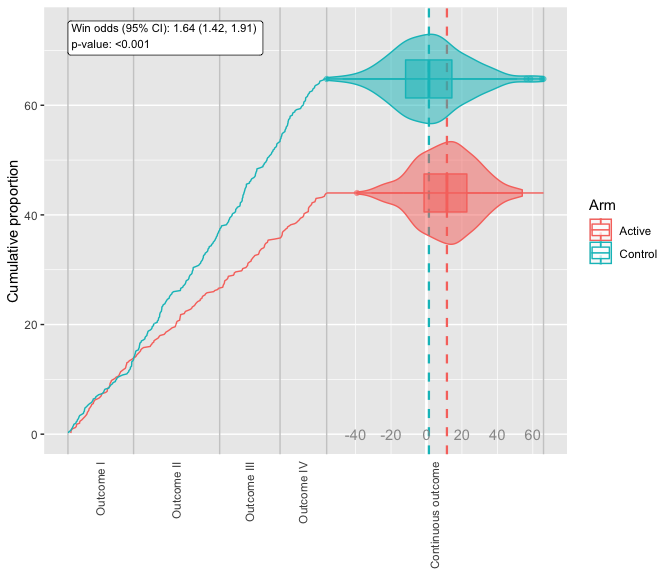

```r
plot(mar, continuous_grid_spacing_x = 20)
```

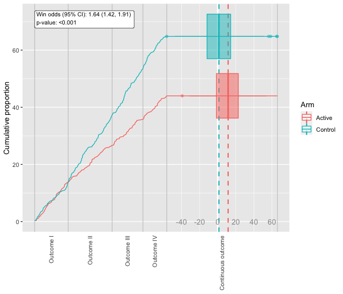

```r
plot(mar, continuous_grid_spacing_x = 20, density_plot_type = "box")
```

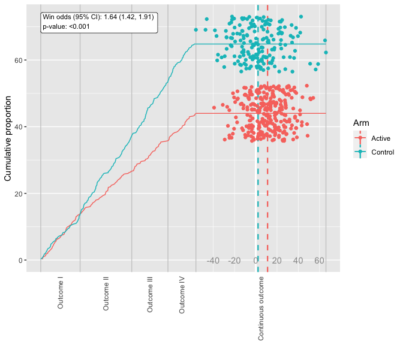

```r
plot(mar, continuous_grid_spacing_x = 20, density_plot_type = "scatter", vline_type = "mean")
```

The plot_maraca function returns a ggplot2 object. This function will not render the plot immediately so you will have to print() it. Conveniently, you can customize your maraca plot with the comprehensive toolbox of ggplot2. For example:

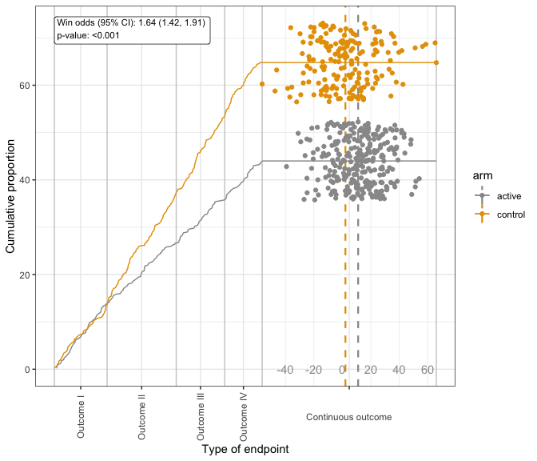

```r
p <- plot_maraca(mar, continuous_grid_spacing_x = 20, density_plot_type = "scatter", vline_type = "mean")
p +
  theme_bw() + scale_color_manual(values=c("#999999", "#E69F00")) +
  theme(axis.text.x.bottom = element_text(angle = c(90,90,90,90,0), vjust = 0.5, hjust = 0.5))
```

Additionally, there are a few supporting plots that can be used to look closer at the time-to-event outcomes. `plot_tte_components` provides a one-row grid of the TTE outcomes Kaplan-Meier plots.

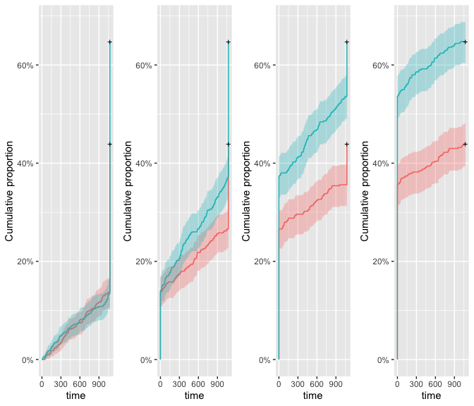

```r
plot_tte_components(mar)
```

`plot_tte_composite` plots the Kaplan-Meier plot for the composite of all specified events. The plot is also annotated with the hazard ratio (more info in `mar$survmod_complete`).

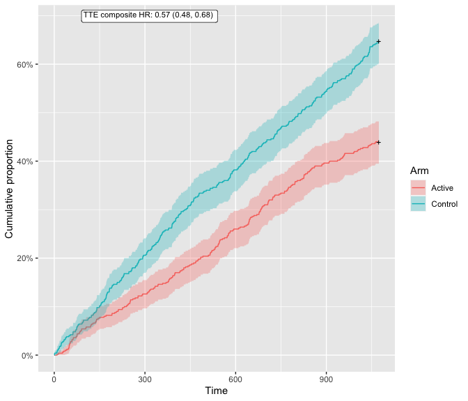

```r
plot_tte_composite(mar)
```

# References

Martin Karpefors, Daniel Lindholm and Samvel B. Gasparyan, “The maraca plot – a novel visualization of hierarchical composite endpoints”, submitted to Clinical Trials, August 2022.